# PracticalMachineLearning

Peter Tan

02/24/2016

## Background

Using devices such as Jawbone Up, Nike FuelBand, and Fitbit it is now possible to collect a large amount of data about personal activity relatively inexpensively. These type of devices are part of the quantified self movement – a group of enthusiasts who take measurements about themselves regularly to improve their health, to find patterns in their behavior, or because they are tech geeks. One thing that people regularly do is quantify how much of a particular activity they do, but they rarely quantify how well they do it. In this project, your goal will be to use data from accelerometers on the belt, forearm, arm, and dumbell of 6 participants. They were asked to perform barbell lifts correctly and incorrectly in 5 different ways. More information is available from the website here: http://groupware.les.inf.puc-rio.br/har (see the section on the Weight Lifting Exercise Dataset).

## Data

The training data for this project are available here:

https://d396qusza40orc.cloudfront.net/predmachlearn/pml-training.csv

The test data are available here:

https://d396qusza40orc.cloudfront.net/predmachlearn/pml-testing.csv

```r
#load the necessary library
library(RCurl)
library(caret)
library(randomForest)
```

```r
library(ggplot2)
library(gbm)
library(rpart)
```

# Preprocess data

In this step, we want to import our data in and set any missing value to be NA. That way, we can then replace the NA value to 0 and submit entire data set through our machine learning exercise.

```r
#Import the training data set
trainingURL <- getURL("https://d396qusza40orc.cloudfront.net/predmachlearn/pml-training.csv")
trainingData <- read.csv(text = trainingURL , na.strings=c("NA","#DIV/0!", ""))

#Import the final testing data set
testingURL <- getURL("https://d396qusza40orc.cloudfront.net/predmachlearn/pml-testing.csv")
testingData <- read.csv(text = testingURL, na.strings=c("NA","#DIV/0!", ""))

#Replace all the NA value to 0
trainingData[is.na(trainingData)] <- 0
testingData[is.na(testingData)] <- 0

#Remove the non-feature columns from the data frame
trainingData <- trainingData[, -c(1:7)]
testingData <- testingData[, -c(1:7)]
```

## Split data set into training and testing to train our model

We want to split our training data set into training and testing so we can do cross validation against our model.

```r
inTrain <- createDataPartition(trainingData$classe, p=.70, list=FALSE)
training <- trainingData[inTrain,]
testing <- trainingData[-inTrain,]
```

# Exploratory Analysis

Based on the bar graph below, we can see that class A has the most count.

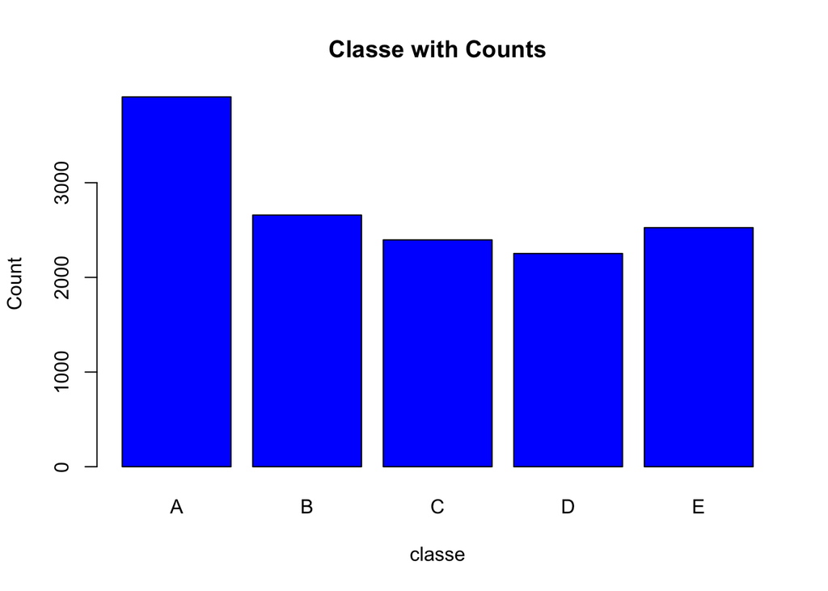

```r
plot(training$classe, col="blue", main="Classe with Counts", xlab="classe", ylab="Count")
```

## Machine Learning

First machine learning approach -> Decision Tree

```r
#Train our decision tree model
model.rpart <- rpart(classe ~ ., data=training, method="class")

# Predicting
predict.rpart <- predict(model.rpart, testing, type = "class")
#Review the accuracy
confusionMatrix(predict.rpart, testing$classe)
```

```
## Confusion Matrix and Statistics
##
##           Reference
## Prediction    A    B    C    D    E
##          A 1473  176   19   35   17
##          B   52  713   92   83  107
##          C   40  112  823  155  131
##          D   70   72   76  596   56
##          E   39   66   16   95  771
##
## Overall Statistics
##
##                Accuracy : 0.7436
##                  95% CI : (0.7322, 0.7547)
##     No Information Rate : 0.2845
##     P-Value [Acc > NIR] : < 2.2e-16
##
##                   Kappa : 0.6754
##  Mcnemar's Test P-Value : < 2.2e-16
##
## Statistics by Class:
##
##                      Class: A Class: B Class: C Class: D Class: E
## Sensitivity            0.8799   0.6260   0.8021   0.6183   0.7126
## Specificity            0.9413   0.9296   0.9099   0.9443   0.9550
## Pos Pred Value         0.8564   0.6810   0.6527   0.6851   0.7812
## Neg Pred Value         0.9517   0.9119   0.9561   0.9266   0.9365
## Prevalence             0.2845   0.1935   0.1743   0.1638   0.1839
## Detection Rate         0.2503   0.1212   0.1398   0.1013   0.1310
## Detection Prevalence   0.2923   0.1779   0.2143   0.1478   0.1677
## Balanced Accuracy      0.9106   0.7778   0.8560   0.7813   0.8338
```

Second machine learning approach -> GBM

```r
model.gbm <- train(classe ~ ., method="gbm", data=training, verbose=FALSE)
predict.gbm<- predict(model.gbm, testing)
confusionMatrix(predict.gbm, testing$classe)
```

```
## Confusion Matrix and Statistics
##
##           Reference
## Prediction    A    B    C    D    E
##          A 1652   25    0    0    1
##          B   14 1081   41    4   14
##          C    3   28  961   26    9
##          D    4    2   21  929   15
##          E    1    3    3    5 1043
##
## Overall Statistics
##
##                Accuracy : 0.9628
##                  95% CI : (0.9576, 0.9675)
##     No Information Rate : 0.2845
##     P-Value [Acc > NIR] : < 2.2e-16
##
##                   Kappa : 0.9529
##  Mcnemar's Test P-Value : 0.001309
##
## Statistics by Class:
##
##                      Class: A Class: B Class: C Class: D Class: E
## Sensitivity            0.9869   0.9491   0.9366   0.9637   0.9640
## Specificity            0.9938   0.9846   0.9864   0.9915   0.9975
## Pos Pred Value         0.9845   0.9367   0.9357   0.9567   0.9886
## Neg Pred Value         0.9948   0.9877   0.9866   0.9929   0.9919
## Prevalence             0.2845   0.1935   0.1743   0.1638   0.1839
## Detection Rate         0.2807   0.1837   0.1633   0.1579   0.1772
## Detection Prevalence   0.2851   0.1961   0.1745   0.1650   0.1793
## Balanced Accuracy      0.9903   0.9668   0.9615   0.9776   0.9807
```

Third machine learning approach -> Random Forest

```r
model.rf <- train(classe ~ ., method="rf", data=training, type="class")
predict.rf<- predict(model.rf, testing)
confusionMatrix(predict.rf, testing$classe)
```

```
## Confusion Matrix and Statistics
##
##           Reference
## Prediction    A    B    C    D    E
##          A 1672   11    0    0    0
##          B    2 1126    9    0    1
##          C    0    2 1012   16    2
##          D    0    0    5  948    5
##          E    0    0    0    0 1074
##
## Overall Statistics
##
##                Accuracy : 0.991
##                  95% CI : (0.9882, 0.9932)
##     No Information Rate : 0.2845
##     P-Value [Acc > NIR] : < 2.2e-16
##
##                   Kappa : 0.9886
##  Mcnemar's Test P-Value : NA
##
## Statistics by Class:
##
##                      Class: A Class: B Class: C Class: D Class: E
## Sensitivity            0.9988   0.9886   0.9864   0.9834   0.9926
## Specificity            0.9974   0.9975   0.9959   0.9980   1.0000
## Pos Pred Value         0.9935   0.9895   0.9806   0.9896   1.0000
## Neg Pred Value         0.9995   0.9973   0.9971   0.9968   0.9983
## Prevalence             0.2845   0.1935   0.1743   0.1638   0.1839
## Detection Rate         0.2841   0.1913   0.1720   0.1611   0.1825
## Detection Prevalence   0.2860   0.1934   0.1754   0.1628   0.1825
## Balanced Accuracy      0.9981   0.9930   0.9911   0.9907   0.9963
```

Based off the accuracy comparison above, Random Forest gives us the highest accuracy. So we will use the Random Forest to perform the final prediction against the test data set

```r
prediction <- predict(model.rf, testingData)
prediction
```

```
##  [1] B A B A A E D B A A B C B A E E A B B B
## Levels: A B C D E
```

Finally, we are going to save the output

```r
product_createFile = function(x) {
  n = length(x)
  for (i in 1:n) {
    filename = paste0("problem_id_", i, ".txt")
    write.table(x[i], file = filename, quote = FALSE, row.names = FALSE,
                col.names = FALSE)
  }
}

product_createFile(prediction)
```

link to github: https://github.com/Alucarrd/PracticalMachineLearning